# Cuadrado latino

Gerardo Martín

30/3/2021

# 1 Introducción

El diseño de cuadrado latino se propuso en estudios de agricultura para:

1. Exponer las réplicas de los diferentes tratamientos experimentales a la mayor cantidad posible de efectos ambientales no medidos
2. Combinar los diferentes tratamientos de experimentos factoriales

Físicamente, lo que define al cuadrado latino es que en cada fila y columna aparece sólo una vez cada tratamiento de un factor o combinación de factores (en experimentos factoriales). Para justificar la utilización de un cuadrado latino es necesario identificar si:

1. Existe algún componente heterogéneo en el espacio físico que afectará el comportamiento de los tratamientos experimentales
2. El espacio es compatible con el tamaño mínimo de las parcelas para el experimento
3. Hay espacio suficiente en cada parcela para la operación de algún equipo especializado para su mantenimiento o para registrar las observaciones o mediciones

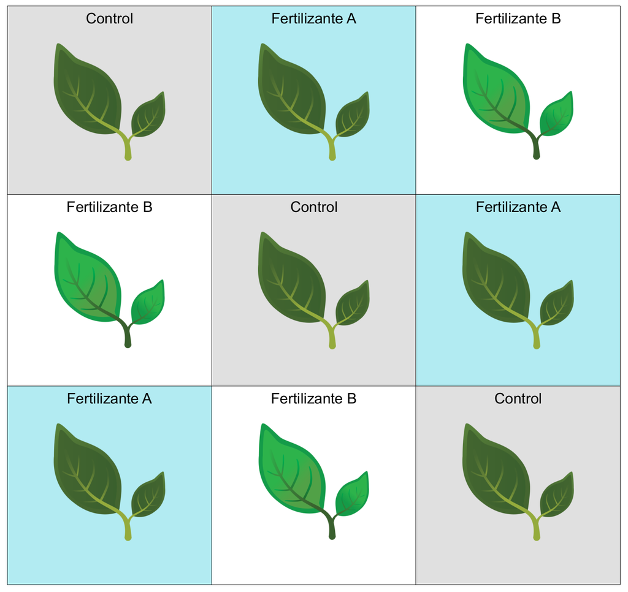

Figure 1.1: Diseño de cuadrado latino para aumentar la heterogeneidad de los factores externos.

El cuadrado latino de la figura 1.1 aumenta la variedad de condiciones ambientales para cada tratamiento. Para el mismo experimento, existen pocas variantes posibles del cuadrado pues solamente cuenta con tres tratamientos, pues el número de cuadrados latinos posibles aumenta considerablemente con el número de tratamientos (los cuadrados se pueden aleatorizar mientras se cumpla la condición de no-repetición por fila y columna). El diseño de cuadrado latino tiene importantes limitantes para diseños de una vía, por ejemplo si el experimento cuenta con pocos tratamientos, como en la figura 1.1, habrá pocas réplicas. La misma limitación tiene implicaciones importantes en diseños factoriales:

1. Sólo permite realizar experimentos con factores con el mismo número de niveles
2. Sólo permite estimar efectos aditivos

# 2 Limitaciones del cuadrado latino para diseños factoriales

Para comenzar consideremos un diseño de dos factores con tres niveles cada uno:

$$\mathrm{Factor\ A} = \{a, b, c \}$$
$$\mathrm{Factor\ B} = \{\alpha, \beta, \gamma \}$$
lo que resulta en un total de combinaciones de $3 \times 3 = 9$. Con base en la única condición del cuadrado latino, tendríamos que todas las combinaciones posibles de tratamientos quedarían ubicadas cada una en una celda del cuadrado:

| $a, \alpha$ | $b, \beta$ | $c, \gamma$ |
| --- | --- | --- |
| $c, \beta$ | $a, \gamma$ | $b, \alpha$ |
| $b, \gamma$ | $c, \alpha$ | $a, \beta$ |

Si vemos con atención, tenemos que cada tratamiento aparece tres veces, por lo que cada uno cuenta con dos grados de libertad, sin embargo, las combinaciones de tratamientos –la interacción $A:B$– sólo aparecen una vez, y por lo tanto, no tienen grados de libertad. Es por ello que no es posible estimar los efectos estadísticos de la interacción. Entonces, cuando se tiene un diseño de cuadrado latino para hacer las combinaciones de tratamientos sólo se puede ajustar un modelo con efectos aditivos `y ~ x1 + x2`, sin los términos `*` o `:`.

Para poder estimar los efectos de las interacciones, entonces, sería necesario contar con repeticiones del cuadrado greco-latino. Como hemos visto anteriormente, las interacciones pueden o no occurrir en el mundo real (análisis de `npk` por ejemplo). Entonces, la decisión de utilizar cuadrado latino o no para el diseño experimental debe tomar en cuenta si es necesario estimar la interacción entre los factores experimentales.

Cuanto es posible contar con suficientes repeticiones del cuadrado latino el análisis será igual a un ANOVA de dos vías con interacciones y efectos mixtos (El factor de agrupación experimental será cada cuadrado latino). El número de cuadrados latinos necesarios para estimar las interacciones es $N+1$ ($N$, número de tratamientos experimentales $N$).

Regresar al índice del curso